# Exploratory Data Analysis

Statistical and Geospatial Modelling

Alejandro Ordonez

10/09/2021

# Instructions

## Before we start

The practical will be run using *RStudio cloud* to avoid individual machine trouble shooting. This means you **need** to have an account for *RStudio cloud*.

However, remember to have `R` (https://cran.r-project.org) and R-studio (http://www.rstudio.com/) in your/room computer so you can work on the project after class.

## The goal.

The goal of this practical is to implement what we have learned in the class about Exploratory Data Analysis in `R`. **You should have read chapter 2 of Borcard, Daniel, Francois Gillet, and Pierre Legendre. Numerical ecology with R. Springer, 2018.**

## Learning objectives.

1. Graphically explore the variability in the variables in a data set based.
2. Graphically compare the variables values between two categorical groups
3. Determine the correlation between two random variables and the significance of such correlation.
4. Establish the normality of a variable.

## The way it’s going to be run.

A 3h practical divided into two parts. **DO NOT COPY AND PASTE THE CODE!** Write your own `R`-code and run it, that is the best way to learn how this program works. Also, you have an excellent Teaching assistant resource - ask him and/or me all the questions you have.

The text in the blue box marked as **Your task:** states what you need to do

```r
# The code in the window marked like this shows where you need to write your code
#
# If I ask you to make an assessment of the result, you should write the text here as a comment starting with two hashes (##)
```

This time around, you will work with Real Biological Data, coming from Scientific publications. In this way you will get hands on experience with the type of information coming from scientific studies.

## Assessment.

Submit your `R-markdown` file via BrightSpace - **Before the next practical!** **The assessment is a Pass/Fail based on how you write and annotate the code - You need to show us you know what you are doing and NOT copying the code of someone else.**

# Before you start.

Exploratory data analysis (EDA) is the process by which a person manipulates data with the goal of learning about general patterns or tendencies and finding specific occurrences that deviate from the general patterns. Many statisticians have devised a collection of methods helpful in exploring data. However, the specific data analysis techniques are useful, exploratory data analysis is more than the methods – it represents an attitude or philosophy about how data should be explored.

EDA is an iterative cycle that helps you understand what your data says. When you do EDA, you:

1. Generate questions about your data
2. Search for answers by visualizing, transforming, and/or modeling your data
3. Use what you learn to refine your questions and/or generate new questions

EDA is an important part of any data analysis. You can use EDA to make discoveries about the world; or you can use EDA to ensure the quality of your data, asking questions about whether the data meets your standards or not.

Your goal during EDA is to develop an understanding of your data. The easiest way to do this is to use questions as tools to guide your investigation. When you ask a question, the question focuses your attention on a specific part of your dataset and helps you decide which graphs, models, or transformations to make.

EDA is, fundamentally, a creative process. And like most creative processes, the key to asking quality questions is to generate a large quantity of questions. It is difficult to ask revealing questions at the start of your analysis because you do not know what insights are contained in your dataset. On the other hand, each new question that you ask will highlight a new aspect of your data and increase your chance of making a discovery. You can quickly drill down into the most interesting parts of your data—and develop a set of thought-provoking questions—if you follow up each question with a new question based on what you find.

# Crab and Burrow Density on Christmas Island

*[Green, P.T. (1997) Red crabs in rain forest on Christmas Island, Indian Ocean: activity patterns, density and biomass. Journal of Tropical Ecology 13: 17-38.]*

The data at hand comes from Green (1997), who studied the ecology of red land crabs on Christmas Island and examined the relationship between the total biomass of red land crabs and the density of their burrows within 25-m2 quadrats (sampling units) at five forested sites on the island. For simplicity We will look at two of these sites. The database includes information on total biomass (`TOTMASS`) and density of burrows (`BURROWS`) for ten quadrants (`QUADNUM`) at Lower Site (`LS`) and eight quadrants (`QUADNUM`) at Drum site (`DS`).

## The first step: Loading the data

The first step, you will have to take when making any data analysis is to load your data. `R` can load data in many different formats, but the two most common are: * CSV files * Text files

CSV means Comma Separated Values. You can export CSV files from many data carrying applications. For instance, you can export CSV files from data in an Excel spreadsheet. A text file is typically similar to a CSV file, but instead of using commas as separators between values, text files often use other characters, like e.g. a Tab character.

The easiest way to load data into memory in `R` is by using the R Studio menu items. Instead we will use the second option: `R` three different functions to import data. You will use this approach as the objective is to get familiar with “the”coding" your analyses.

As said before, `R` has three different functions which can import tabular data (that is table with *columns* for individual variable and *rows* for observations). These are: * `read.table()` that loads data from a file into a tabular data set (table) in memory. * `read.csv()` that reads a CSV file into the memory. * `read.delim()` that reads a CSV file into the memory, just like the `read.csv()` function, but define the character separating the columns.

These functions are very similar to each other, so if you master one of them you will soon master the others. In fact, you can probably just use the `read.table()` function for all of your data imports. The `read.table()` function takes three parameters: * The file name of the file to load (which can be a location in your hard drive or a Web URL) * A flag telling if the file contains a header line. * The separator character used inside the file to separate the values of each row.

For example, `read.table('./data/file_name.txt', header = T, sep = '\t')` will import the information in `file_name.txt`, assuming that the first row has the variable names, and that the columns are separated by TAB.

By comparison, `read.csv()` and `read.delim()`, assume that there is a header, and `read.csv()` assumes that the separator is a `,`.

**Your task:**

Load the data from *green.csv*, located in the Web URL https://raw.githubusercontent.com/AlejoOrdonez/StaGeoMod2021/main/green.csv. For this:

- Define an object named URL.Loc with the string of the Web URL.
- Use `read.table` to load the file - The file is comma-separated

```r
## Define an object named URL.Loc with the string of the Web URL
URL.Loc <- "https://raw.githubusercontent.com/AlejoOrdonez/StaGeoMod2021/main/green.csv"

## Use `read.table` to load the file and save it as an object named green
## The file green.csv is a Comma-separated file

green <- read.table(
  file = URL.Loc,
  header = T,
  sep = ","
)
```

## What is the Table?

To make the discussion easier, let’s define some terms

A **variable** is a quantity, quality, or property that you can measure. You can look at the names of these using the functions `names` or `colnames`

A **value** is the state of a variable when you measure it. The value of a variable may change from measurement to measurement. You can extract specific values by addressing the specific row within the variable of interest for a given observation.

An **observation** or case is a set of measurements made under similar conditions (you usually make all of the measurements in an observation at the same time and on the same object). An observation will contain several values, each associated with a different variable. I’ll sometimes refer to an observation as a case or data point. You can extract the observation by addressing the respective row number.

**Tabular data** is a table of values, each associated with a variable and an observation. Tabular data is tidy if each value is placed in its own cell, each variable in its own column, and each observation in its own row.

**Your task:**

Based on the data stored in the object `green` answer the following questions:

- Which are the variable names in the `green` data set?
- Which value in the has the third Drum site quadrant observation for the `TOTMASS` variable.
- Which is the second observation for the Lower site on the `green` data set?

```r
# Which are the variable names in the `green` data set?
names(green)
```

```
## [1] "ID"      "SITE"    "QUADNUM" "TOTMASS" "BURROWS"
```

```r
colnames(green)
```

```
## [1] "ID"      "SITE"    "QUADNUM" "TOTMASS" "BURROWS"
```

```r
# Which value in the has the third Drum site quadrant observation for the `TOTMASS` variable.
green$TOTMASS[c(green$SITE == "DS" & green$QUADNUM == 3)]
```

```
## [1] 4.31
```

```r
# Which  is the second observation for the Lower Site site on the `green` data set?
green[c(green$SITE == "LS" & green$QUADNUM == 2), ]
```

```
##    ID SITE QUADNUM TOTMASS BURROWS
## 10 10   LS       2    4.01      37
```

## Two useful questions

There is no rule about which questions you should ask to guide your research. However, two types of questions will always be useful for making discoveries within your data. You can loosely word these questions as: * What type of **variation** occurs **within** my variables? * What type of **covariation** occurs **between** my variables?

*But what is variation?*, Variation is the tendency of the values of a variable to change from measurement to measurement. You can see variation easily in real life; if you measure any continuous variable twice—and precisely enough—you will get two different results. This is true even if you measure quantities that are constant, like the speed of light. Each of your measurements will include a small amount of error that varies from measurement to measurement. Categorical variables can also vary if you measure across different objects (e.g. the eye colors of different people), or different times (e.g. the energy levels of an electron at different moments).

Every variable has its own pattern of variation, which can reveal useful information. The best way to understand that pattern is to visualize the distribution of the variable’s values. How you visualize the distribution of a variable will depend on whether the variable is categorical or continuous.

**Categorical variables**: A variable is categorical if it can take only one of a small set of values. In `R`, categorical variables are usually saved as factors or character vectors. You can visualize the distribution of a categorical variable with a bar chart using the `barplot` function.

**Continuous variables** A variable is continuous if it can take any of an infinite set of smooth, ordered values. Here, smooth means that if you order the values on a line, an infinite number of values would exist between any two points on the line. For example, an infinite number of values exists between 0 and 1, e.g. 0.9, 0.99, 0.999, and so on. You can visualize the distribution of a continuous variable with a histogram using the `hist` function.

**Your task:**

Based on the data stored in the object `green` you will plot:

Now answer these questions:

- Do the histograms look normally distributed/skewed?, can you detect the presence of outlines?
- What is the difference between making a histogram of DensityLS and plotting the density of BiomassLS?

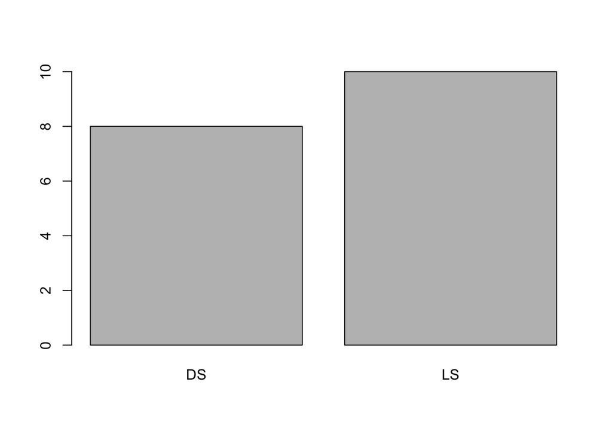

```r
## Plot a barplot summarizing the number of Quadrants per site.
### Create a object named TotSite that contains the count of observations for each site
TotSite <- table(green$SITE)
### use barplot to create a figure with the number of Quadrants per site.
barplot(TotSite)
```

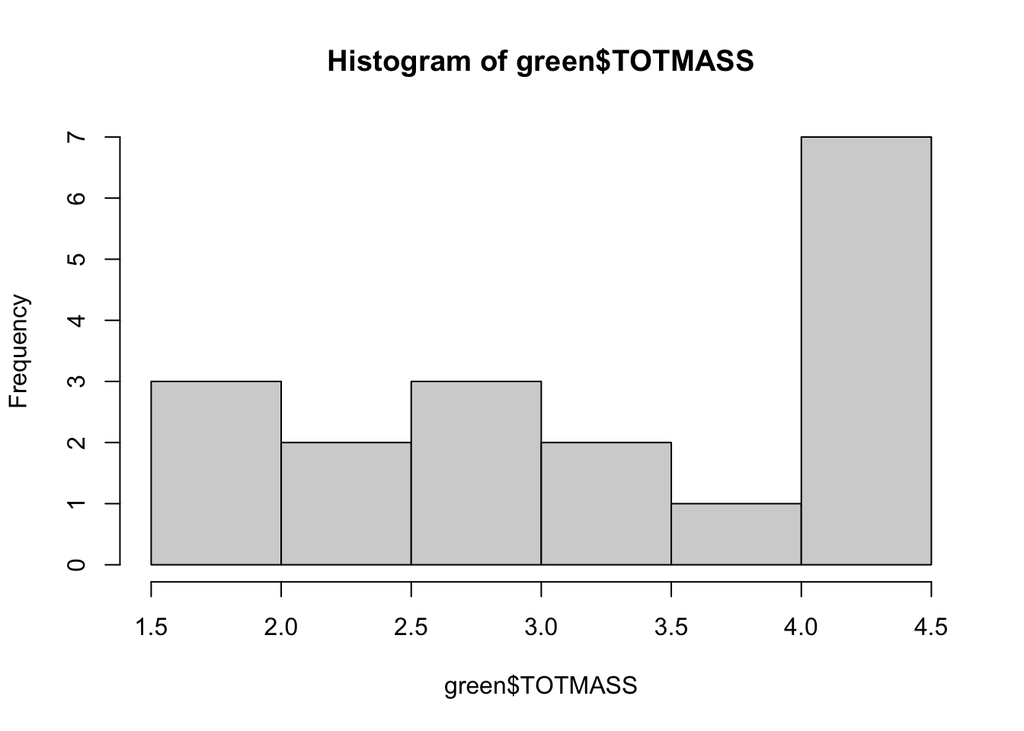

```r
## Plot a histogram for total biomass for **all** Sites.
hist(green$TOTMASS)
```

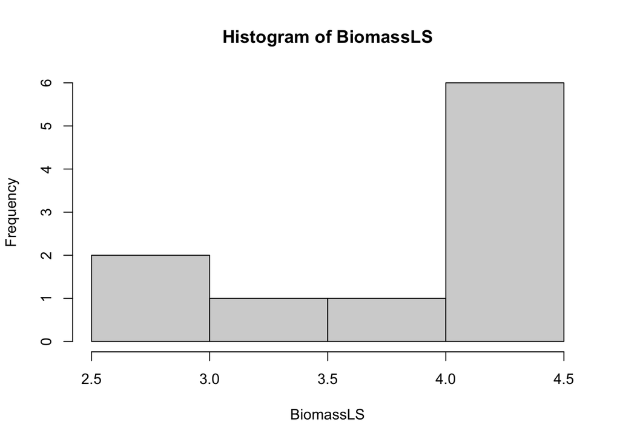

```r
## Plot a histogram for the density of burrows for **Lower side** Sites. For this
### Create a object named BiomassLS that has the information on biomass for Lower side sites
BiomassLS <- green$TOTMASS[green$SITE == "LS"]
### PLot a histogram using BiomassLS
hist(BiomassLS)
```

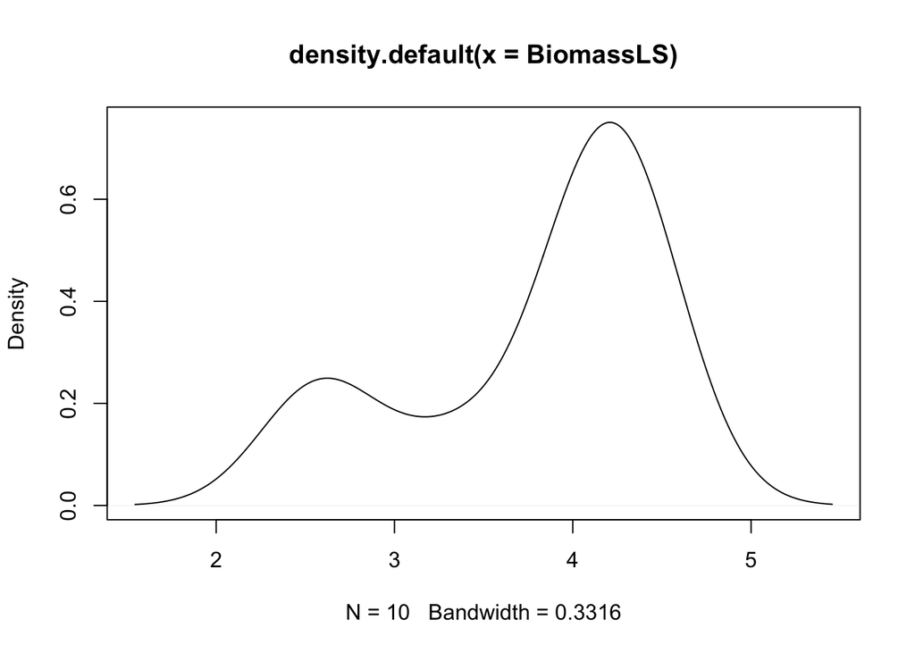

```r
### Now use the function density on BiomassLS to create an object call DensityLS
DensityLS <- density(BiomassLS)
### plot DensityLS
plot(DensityLS)
```

```r
# Do the histograms look normally distributed/skewed?, can you detect the presence of outlines?
### No they don't they look, bimodal.


### What is the difference between making a histogram of DensityLS and plotting the density of BiomassLS?
## histograms counts the number of observation on predefined classes, Density is a smoothed function of the expected "kernel density" estimates
```

## Beyond Frequencies

In both bar charts and histograms/density plots, tall bars show the common values of a variable, i.e. the values that appear frequently. Shorter bars show less-common values, i.e. values that appear infrequently. Places that do not have bars reveal values that were not seen in your data. To turn this information into useful questions, look for anything unexpected:

- Which values are the most common? Why?
- Which values are rare? Why? Does that match your expectations?
- Can you see any unusual patterns? What might explain them?
- Are there any outliers, which are points that don’t fit the pattern or fall far away from the rest of the data
- Are outliers the result of data entry errors or something else?

Many of the questions above will prompt you to explore the differences between groups, to see if the values of one group are larger/smaller than that of the group(s).

**Your task:**

Based on the data stored in the object `green` you will plot:

- A boxplot summarizing the total biomass per site.
- A boxplot summarizing the burrows density per site.
- Do you see any difference between the `DS` and `LS` site?

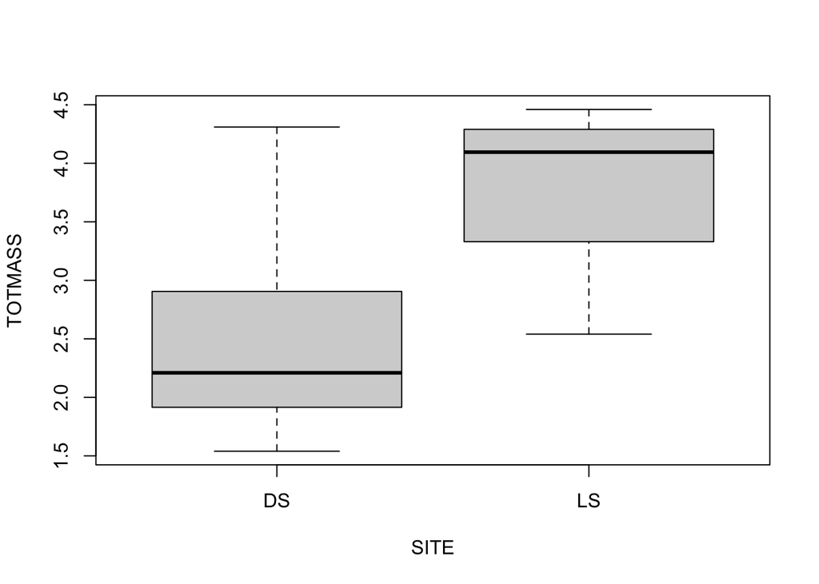

```r
# Plot a boxplot summarizing the total biomass per site.
### box-Plots illustrate the Min-Max values (lower/upper whisker), inter-quantile range (Box lower/upper edges), and the median (center Thick line)
boxplot(TOTMASS ~ SITE, # PLace what you what to plot here as a formula VarToPlot ~ GroupingVar
  data = green
) # name of the Object with the data
```

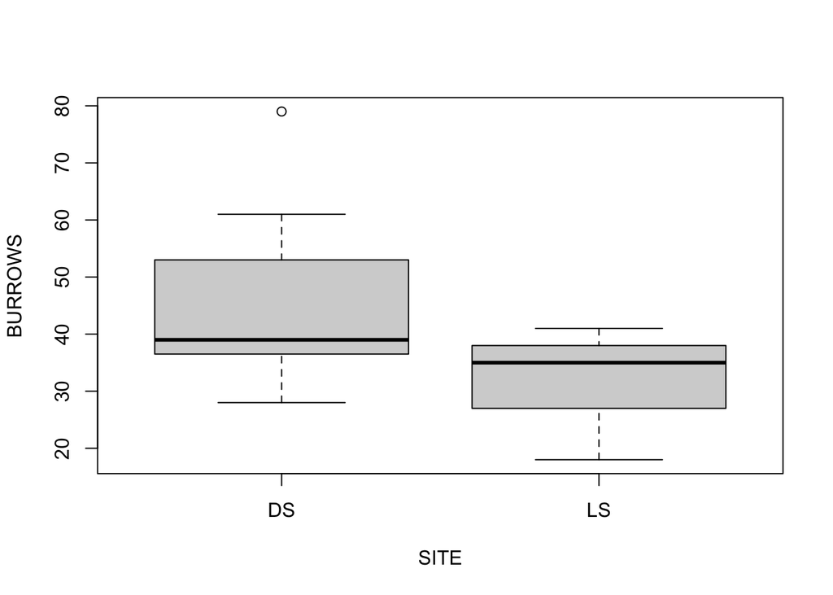

```r
# Plot a boxplot summarizing the Burrows density per site.
boxplot(BURROWS ~ SITE, # PLace what you what to plot here as a formula VarToPlot ~ GroupingVar
  data = green
) # name of the Object with the data
```

```r
# Do you see any difference between the `DS` and `LS` site?
### DS sites have on average lower biomass, and a higher burrows density.
```